# Udacity capstone - pt.1 data exploration

## Udacity Nanodegree Capstone Project

### Predicting ICU mortality based on MIMIC-III database

This is the capstone project for Udacity's machine learning project. I am in terested to find out whether patient mortality could be better predicted using different medical record data instead of solely relying on severity scores such as SAPS, etc, which used logistic regression. As a binary classification problem, we have a lot of options in machine learning algorithms. In this project, I intended to test other machine learning algorithms, such as support vector machine and random forest, optimize their performance by tuning hyperparameters,and come up with predictive models with better accuracy for ICU mortality.

The MIMIC-III is a free database, which contains over 60,000 hospital admission data for ICU patients. Medical information was aggregated from many different sources, e.g., hospital admission, ICU charted information, laboratory analysis reports, etc. Therefore, there exist many tables that documents relevant medical history about admitted patients, including lab analysis records, and charted data in ICU care. Without a background in medicine and ICU care, it is a challenge to make sense of the sophisticated data library. To make sense of the what the data actually represent, relevant literatures were collected and read by the author. To be able to gather information important to mortality prediction, structured query language (sql) scripts were first run to compile the libraries from downloaded csv files. Based on selection criteria, new sql script was written to extract necessary information for this project. The sql script was written for postgresql database and is attached to the project report.

### Section 1. Data extraction and cleansing

In this section, I am going to establish connection with mimiciii database on my local computer and return a table that contains all the medical record information from a query. The master data table was extracted from the mimiciii database using a sql script that I wrote, which pulled relevant medical information and aggregate some of the data from multiple tables in the mimiciii database. I then use pandas dataframe to store the extract the medical information, which satisfy my screening criteria.

```python
import numpy as np
import random
import pandas as pd
import psycopg2
import matplotlib.pyplot as plt
import sys
```

The mimiciii database occupy about 70 GB on my local drive. Not all information is needed and some of the data, e.g., heartrate, must to be presented in aggregated form. The aggregated information was stored in a master table. In the next section, parameters to setup database connection was assigned.

```python
username='postgres'
database='mimic'
schema='mimiciii'
server='localhost'
port=5432
password='Dba2018'
try:
    con=psycopg2.connect(dbname=database, user=username,host=server,password=password)
except:
    print("Failed to establish connection with database")
```

All aggregated information was saved in table "D_total" in the mimiciii database. there are about 50 different fields that need to be queried. The next section send out query to extract the master table containing all variables. A summary table of the available features is provided to give me an overview about how each feature behave statistically.

```python
cur=con.cursor()
query_env='SET search_path to '+ schema + ';'
cur.execute(query_env)


query_data='SELECT * FROM D_TOTAL;'

df_master=pd.read_sql_query(query_data,con)
print('The shape for the data is {} by {}'.format(*df_master.shape))
cur.close()
con.close()
```

```
The shape for the data is 51907 by 51
```

```python
pd.set_option('display.precision',2)
df_master.iloc[:,3:].describe().transpose()
```

|  | count | mean | std | min | 25% | 50% | 75% | max |
| --- | --- | --- | --- | --- | --- | --- | --- | --- |
| male_flag | 51907.0 | 0.56 | 0.50 | 0.00 | 0.00 | 1.00 | 1.00 | 1.00e+00 |
| emergency_admission | 51907.0 | 0.86 | 0.35 | 0.00 | 1.00 | 1.00 | 1.00 | 1.00e+00 |
| ethnic_other | 51907.0 | 0.13 | 0.34 | 0.00 | 0.00 | 0.00 | 0.00 | 1.00e+00 |
| ethnic_asian | 51907.0 | 0.02 | 0.15 | 0.00 | 0.00 | 0.00 | 0.00 | 1.00e+00 |
| ethnic_hispanic | 51907.0 | 0.03 | 0.18 | 0.00 | 0.00 | 0.00 | 0.00 | 1.00e+00 |
| ethnic_black | 51907.0 | 0.10 | 0.29 | 0.00 | 0.00 | 0.00 | 0.00 | 1.00e+00 |
| ethnic_white | 51907.0 | 0.72 | 0.45 | 0.00 | 0.00 | 1.00 | 1.00 | 1.00e+00 |
| hospital_expire_flag | 51907.0 | 0.12 | 0.32 | 0.00 | 0.00 | 0.00 | 0.00 | 1.00e+00 |
| age | 51907.0 | 74.35 | 54.71 | 18.00 | 52.00 | 65.00 | 77.00 | 3.10e+02 |
| icu_los | 51907.0 | 4.21 | 6.20 | 0.04 | 1.23 | 2.17 | 4.24 | 1.73e+02 |
| hosp_los | 51907.0 | 11.31 | 13.18 | -0.77 | 4.25 | 7.36 | 13.35 | 2.95e+02 |
| heartrate | 51907.0 | 84.79 | 13.88 | 29.92 | 75.14 | 84.12 | 93.82 | 1.64e+02 |
| sysbp | 51899.0 | 120.72 | 16.31 | 48.26 | 108.98 | 118.92 | 131.06 | 2.16e+02 |
| diasbp | 51899.0 | 61.00 | 10.44 | 22.56 | 53.81 | 60.07 | 67.21 | 1.27e+02 |
| meanbp | 51904.0 | 78.68 | 10.72 | 28.50 | 71.20 | 77.53 | 85.10 | 1.41e+02 |
| resprate | 51882.0 | 19.13 | 3.63 | 7.33 | 16.55 | 18.70 | 21.24 | 4.27e+01 |
| spo2 | 51884.0 | 96.91 | 2.22 | 46.43 | 96.04 | 97.20 | 98.21 | 1.00e+02 |
| urineoutput | 49803.0 | 8297.20 | 24977.07 | -34950.00 | 1990.00 | 3975.00 | 8305.50 | 4.56e+06 |
| urea | 51796.0 | 25.73 | 18.50 | 1.42 | 13.60 | 19.67 | 31.63 | 2.32e+02 |
| magnesium | 51267.0 | 2.02 | 0.25 | 0.60 | 1.87 | 2.00 | 2.15 | 8.98e+00 |
| calcium | 49919.0 | 8.47 | 0.61 | 2.60 | 8.08 | 8.45 | 8.83 | 1.81e+01 |
| aniongap | 51688.0 | 13.63 | 2.83 | 3.00 | 11.86 | 13.25 | 14.86 | 4.90e+01 |
| albumin | 33065.0 | 3.15 | 0.66 | 1.05 | 2.70 | 3.13 | 3.60 | 5.70e+00 |
| bands | 19525.0 | 3.37 | 5.90 | 0.00 | 0.00 | 1.00 | 4.00 | 6.90e+01 |
| bicarbonate | 51697.0 | 25.40 | 3.88 | 6.00 | 23.33 | 25.41 | 27.38 | 5.20e+01 |
| totalco2 | 37329.0 | 25.80 | 5.17 | 1.00 | 23.06 | 25.54 | 28.00 | 6.35e+01 |
| carboxyhemoglobin | 1610.0 | 1.92 | 1.63 | 0.10 | 1.00 | 1.40 | 2.00 | 2.50e+01 |
| bilirubin | 35351.0 | 1.45 | 3.43 | 0.00 | 0.40 | 0.60 | 1.05 | 5.42e+01 |
| creatinine | 51796.0 | 1.39 | 1.41 | 0.00 | 0.72 | 0.95 | 1.39 | 2.53e+01 |
| chloride | 20908.0 | 104.63 | 6.13 | 3.80 | 101.29 | 105.00 | 108.00 | 1.98e+02 |
| hematocrit | 51806.0 | 31.94 | 4.64 | 12.86 | 28.64 | 31.09 | 34.68 | 6.85e+01 |
| hemoglobin | 51788.0 | 10.75 | 1.65 | 3.73 | 9.59 | 10.46 | 11.71 | 2.10e+01 |
| lactate | 36399.0 | 2.18 | 1.56 | 0.30 | 1.30 | 1.80 | 2.50 | 2.48e+01 |
| o2flow | 7930.0 | 9.29 | 12.43 | 0.40 | 3.00 | 4.00 | 10.00 | 7.00e+01 |
| platelet | 51786.0 | 237.46 | 113.07 | 5.67 | 164.50 | 220.64 | 290.35 | 1.55e+03 |
| potassium | 51803.0 | 4.12 | 0.41 | 1.60 | 3.86 | 4.08 | 4.33 | 7.80e+00 |
| ptt | 49732.0 | 37.23 | 14.98 | 16.00 | 27.20 | 31.80 | 42.58 | 1.50e+02 |
| inr | 49871.0 | 1.43 | 0.62 | 0.60 | 1.11 | 1.25 | 1.49 | 3.24e+01 |
| pt | 49866.0 | 15.32 | 4.72 | 8.57 | 13.00 | 13.95 | 15.76 | 1.50e+02 |
| sodium | 51789.0 | 138.57 | 3.59 | 97.00 | 136.67 | 138.67 | 140.60 | 1.75e+02 |
| tidalvolume | 16104.0 | 558.20 | 152.41 | 1.00 | 473.75 | 540.00 | 630.00 | 6.30e+03 |
| bun | 51796.0 | 25.73 | 18.50 | 1.42 | 13.60 | 19.67 | 31.63 | 2.32e+02 |
| wbc | 51774.0 | 10.92 | 7.41 | 0.10 | 7.81 | 10.08 | 12.80 | 4.68e+02 |
| tempc | 51843.0 | 36.89 | 0.65 | 29.20 | 36.50 | 36.85 | 37.24 | 4.11e+01 |
| glucose | 51855.0 | 133.21 | 38.77 | 29.50 | 110.31 | 124.50 | 144.75 | 7.45e+02 |
| saps | 51907.0 | 18.01 | 5.23 | 0.00 | 14.00 | 18.00 | 21.00 | 4.40e+01 |
| sapsii | 51907.0 | 35.02 | 14.29 | 0.00 | 25.00 | 34.00 | 43.00 | 1.18e+02 |

The summary statistics tells me something more about the dataset that I am going to work with. There is about 56% of the patients are males. 86% of admissions are emergency. Of all included entries, about 12% of patients died in hospital. Average ICU stay is 4 days and average hospital stay is 11 days. A couple variables contains few entries ('carboxyhemoglobin','o2flow','tidalvolume') or have null values throughout ('ventilationrate'). Therefore, it is decided to drop those columns. Also, it was noted in the published paper on MIMICIII that patient age was intentionally offset to 300 for those aged 89 and older (total 2638 patients). I felt the older patient is valuable information, and thus decided to retain those patients in the dataset. There is only a fraction of those patients, thus, they were given a random age between 89-99[1].

[1]Johnson AE, Pollard TJ, Shen L, Lehman LW, Feng M, Ghassemi M, Moody B, Szolovits P, Celi LA, Mark RG. MIMIC-III, a freely accessible critical care database. Scientific Data. 2016;3.

```python
df_master.iloc[:,3:].describe().transpose().round(2).to_csv('stats.csv')
df=df_master.drop(['carboxyhemoglobin','o2flow','ventilationrate','tidalvolume'],axis=1) # columns that are unfit for data analysis
df.head().to_csv('head.csv')
df.head()
```

|  | subject_id | hadm_id | icustay_id | male_flag | emergency_admission | ethnic_other | ethnic_asian | ethnic_hispanic | ethnic_black | ethnic_white | ... | ptt | inr | pt | sodium | bun | wbc | tempc | glucose | saps | sapsii |
| --- | --- | --- | --- | --- | --- | --- | --- | --- | --- | --- | --- | --- | --- | --- | --- | --- | --- | --- | --- | --- | --- |
| 0 | 3 | 145834 | 211552 | 1 | 1 | 0 | 0 | 0 | 0 | 1 | ... | 89.61 | 1.50 | 14.74 | 138.36 | 28.13 | 12.53 | 37.16 | 154.73 | 34 | 79 |
| 1 | 4 | 185777 | 294638 | 0 | 1 | 0 | 0 | 0 | 0 | 1 | ... | 32.25 | 1.05 | 12.55 | 137.75 | 16.12 | 9.44 | 38.90 | 226.75 | 10 | 35 |
| 2 | 6 | 107064 | 228232 | 0 | 0 | 0 | 0 | 0 | 0 | 1 | ... | 53.08 | 1.31 | 13.95 | 134.55 | 53.94 | 13.59 | 36.56 | 124.77 | 18 | 24 |
| 3 | 9 | 150750 | 220597 | 1 | 1 | 1 | 0 | 0 | 0 | 0 | ... | 22.43 | 1.12 | 13.05 | 134.64 | 22.71 | 13.50 | 36.35 | 153.25 | 18 | 31 |
| 4 | 11 | 194540 | 229441 | 0 | 1 | 0 | 0 | 0 | 0 | 1 | ... | 26.28 | 1.08 | 12.47 | 139.14 | 16.00 | 9.86 | 36.82 | 115.45 | 6 | 25 |

5 rows × 47 columns

```python
df.drop(['subject_id','hadm_id'],axis=1,inplace=True) # drop row indexes
df.sort_values('icustay_id', axis=0, ascending=True,inplace=True)
df.loc[df['age']>100,['age']]=random.randint(89,99) # assign a random age for patients with age greater than 100, i.e. 300.
df.fillna(df.mean(),inplace=True) # replace all NAN with mean of that feature. dropping those features would greatly reduce the available data points and led to even more unbalanced dataset.

df.to_csv('fillna.csv')
print('After this round of cleansing, the shape for the data is {} by {}'.format(*df.shape))
print(df['icustay_id'].nunique())
```

```
After this round of cleansing, the shape for the data is 51907 by 45
51907
```

Further cleansing by attempting to remove seemingly outliers in the feature space It still does not feels right by looking at the mean, standard deviation, and max values for each feature. For example, age has values of 300, which was artificially set to protect patient privacy for those who are 89 years and older. I have taken care of the age feature by swapping the 300 with a random number between 89 and 99. For some other features such as hospital_los, pt, wbc, etc. also showed long tails into larger numbers beyond valid values. Without any solid knowledge about what went into those numbers when they were recorded. It is better off to rely on some other methods to detect and remove outlying data points. First of all, I would like to visualize the distribution of those features, which may help discover things that are not easily detected by simply going through the summary statistics.

```python
df=pd.read_csv('fillna.csv')
```

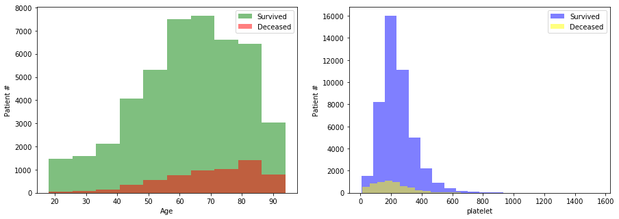

```python
plt.figure()

fig, (ax1,ax2)=plt.subplots(1,2,figsize=(15,5))


ax1.hist(df[df['hospital_expire_flag']==0]["age"].reset_index(drop=True),alpha=0.5,label="Survived",color='green')
ax1.hist(df[df['hospital_expire_flag']==1]["age"].reset_index(drop=True),alpha=0.5,label="Deceased",color='red')
ax1.legend()

ax1.set_xlabel('Age')
ax1.set_ylabel('Patient #')
ax2.axis('tight')

ax2.hist(df[df['hospital_expire_flag']==0]["platelet"].reset_index(drop=True),alpha=0.5,label="Survived",color='blue',bins=20)
ax2.hist(df[df['hospital_expire_flag']==1]["platelet"].reset_index(drop=True),alpha=0.5,label="Deceased",color='yellow',bins=20)
ax2.legend()
ax2.set_xlabel('platelet')
ax2.set_ylabel('Patient #')
ax2.axis('tight')

fig=plt.gcf()
fig.savefig('image.png')

plt.show()
```

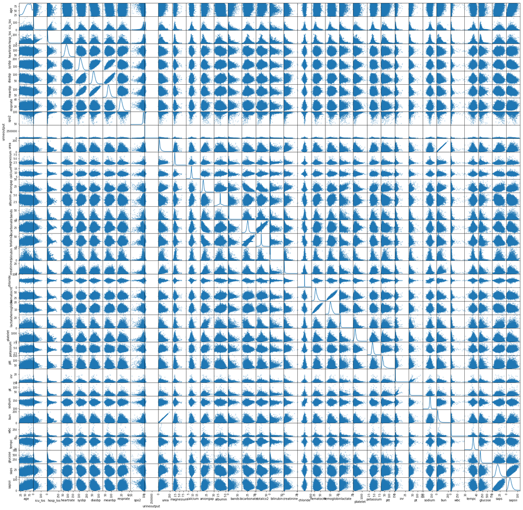

```python
pd.scatter_matrix(df[df.keys()[10:]],alpha=0.3,figsize=(30,30),diagonal='kde') # this would best visualize the histograms for each feature and the correlation among different variables
fig=plt.gcf()
plt.show()
fig.savefig('full.png')
```

```python
import pandas as pd
import numpy as np
import matplotlib.pyplot as plt

df=pd.read_csv('fillna.csv')

def outlier_removal(df,feature):
    df_log=np.log(df[feature])
    Q1,Q3 =np.percentile(df_log,[25,75])
    iqr=Q3-Q1
    lower=Q1-1.5*iqr
    upper=Q3+1.5*iqr
    outlier=df[(df_log<lower)|(df_log>upper)]
    # print(feature,outlier.count())
    return outlier.index

index_buffer=[]
outlier_index=[]
df_out=df.drop(['icustay_id','emergency_admission','heartrate','hospital_expire_flag','age','icu_los','bands','albumin','chloride','totalco2','spo2','magnesium','calcium','aniongap','bicarbonate','bilirubin','platelet','creatinine','potassium','lactate','inr','pt','sodium','wbc','tempc','glucose','ptt','hemoglobin','hematocrit','resprate','saps','sapsii'],axis=1)
for feature in df_out.keys():
    index=outlier_removal(df_out,feature)
    index_buffer=index_buffer+list(index)

outlier_index=list(set(index_buffer))
clean_df=df.drop(outlier_index)
clean_df.to_csv('clean_data.csv')
print(round(clean_df['hospital_expire_flag'].mean(),3))
```

```
0.112
```